# tidy_data_analysis.R

Jess Devine

2025-03-06

```r
# load tidied data
setwd(here())
tidy_data <- readRDS(here("data", "tidy_data.rds"))
```

# Aim:

To determine if incubation period and chick mass vary with rainfall and/or mean maximum temperature, as well as group size.

## Hypothese:

1. Decreased rainfall will be associated with decreased chick mass and will have no association with incubation period.
2. Increased mean maximum temperature will be associated with decreased chick mass and incubation period.
3. These effects will be buffered by group size.

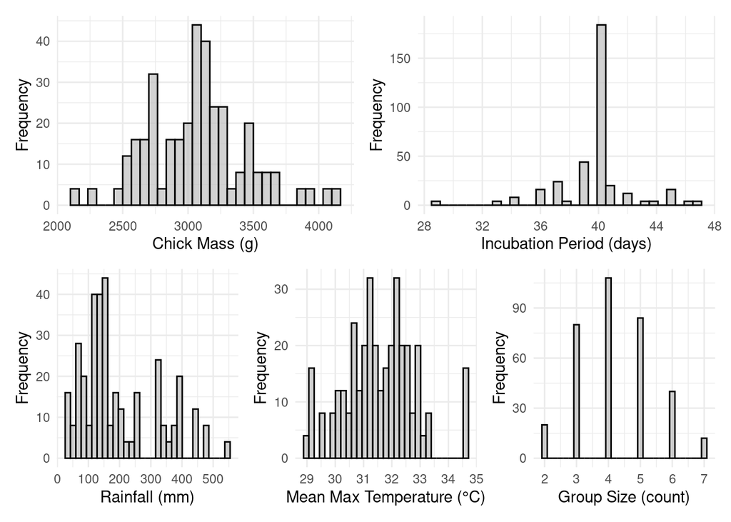

```r
plot_histograms_cleaned <- function(data) {
  vars <- c("Chickmass", "incubation_period", "Rainfallspecific", "meanmaxTspecific", "Groupsize")

  # Define units for each variable
  units <- c("Chick Mass (g)", "Incubation Period (days)", "Rainfall (mm)",
             "Mean Max Temperature (°C)", "Group Size (count)")

  plots <- list()  # Store plots

  for (i in seq_along(vars)) {
    var <- vars[i]
    temp_data <- data

    # Remove NAs only for Chickmass and Groupsize
    if (var %in% c("Chickmass", "Groupsize")) {
      temp_data <- temp_data[!is.na(temp_data[[var]]), ]
    }

    # Adaptive bin width calculation
    bin_width <- (max(temp_data[[var]], na.rm = TRUE) - min(temp_data[[var]], na.rm = TRUE)) / 30

    # Create histogram
    p <- ggplot(temp_data, aes_string(x = var)) +
      geom_histogram(binwidth = bin_width, fill = "grey", color = "black", alpha = 0.7) +
      labs(x = units[i], y = "Frequency") +  # Use labeled units
      theme_minimal()

    plots[[i]] <- p  # Store the plot
  }

  # Arrange all histograms in a panel (2 rows, 3 columns)
  final_plot <- (plots[[1]] + plots[[2]]) / (plots[[3]] + plots[[4]] + plots[[5]]) +
    plot_layout(guides = "collect")

  print(final_plot)  # Display the panel
}

# Call the function on your dataset
plot_histograms_cleaned(tidy_data)
```

**Figure 1:** The distributions of variables of interest.

Group size looks somewhat noramlly ditributed but the other variables are not noramlly distributed.

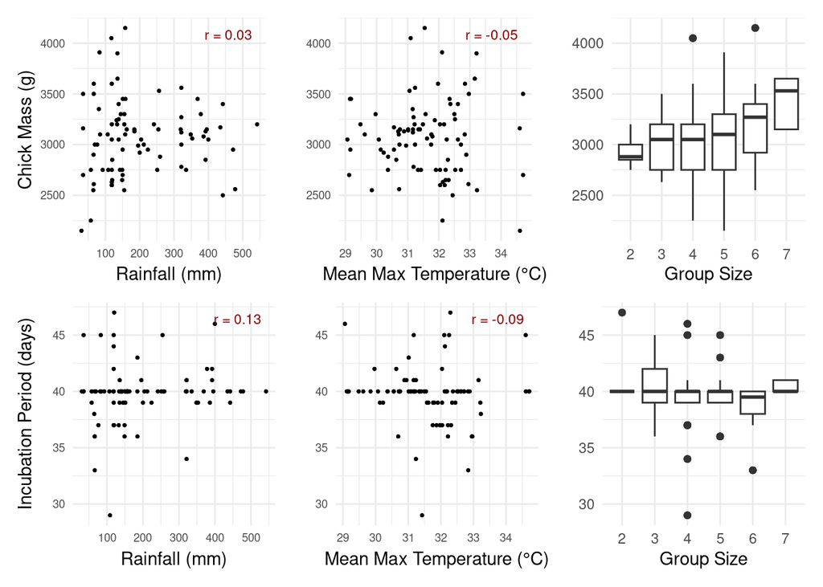

```r
# Function to create scatterplots with r-value annotation
create_scatter <- function(data, x_var, y_var, x_label, y_label) {
  cor_value <- cor(data[[x_var]], data[[y_var]], use = "complete.obs")  # Compute correlation

  ggplot(data, aes(x = .data[[x_var]], y = .data[[y_var]])) +
    geom_point(color = "black", alpha = 0.7, size = 0.5) +
    theme_minimal() +
    labs(x = x_label, y = y_label) +
    annotate("text",
             x = max(data[[x_var]], na.rm = TRUE),
             y = max(data[[y_var]], na.rm = TRUE),
             label = paste0("r = ", round(cor_value, 2)),
             hjust = 1.1, vjust = 1.1,
             size = 3, color = "darkred") + # Adjust text size & color
    theme(
      axis.text = element_text(size = 7)     # Adjusts tick label size
    )
}


# Function to create boxplots
create_boxplot <- function(data, x_var, y_var, x_label, y_label) {
  ggplot(data, aes(x = as.factor(.data[[x_var]]), y = .data[[y_var]])) +
    geom_boxplot() +
    theme_minimal() +
    labs(x = x_label, y = y_label)
}

# Remove NAs only from relevant variables
tidy_data_filtered <- tidy_data %>%
  drop_na(Rainfallspecific, meanmaxTspecific, incubation_period, Chickmass, Groupsize)

# Incubation Period Plots
p1 <- create_scatter(tidy_data_filtered, "Rainfallspecific", "incubation_period", "Rainfall (mm)", "Incubation Period (days)")
p2 <- create_scatter(tidy_data_filtered, "meanmaxTspecific", "incubation_period", "Mean Max Temperature (°C)", "")
p3 <- create_boxplot(tidy_data_filtered, "Groupsize", "incubation_period", "Group Size", "")

# Chick Mass Plots
p4 <- create_scatter(tidy_data_filtered, "Rainfallspecific", "Chickmass", "Rainfall (mm)", "Chick Mass (g)")
p5 <- create_scatter(tidy_data_filtered, "meanmaxTspecific", "Chickmass", "Mean Max Temperature (°C)", "")
p6 <- create_boxplot(tidy_data_filtered, "Groupsize", "Chickmass", "Group Size", "")

# Arrange plots in a 2x3 panel
(p4 + p5 + p6) / (p1 + p2 + p3)
```

The relationship between chick mass and group size looks promising. There don’t seem to be any linear relationships.

Let’s try

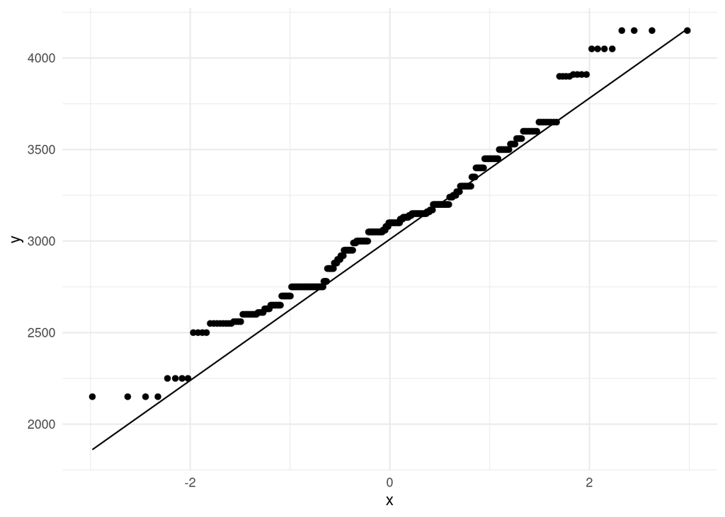

```r
# QQ plots
ggplot(tidy_data, aes(sample = Chickmass)) +
  stat_qq() + stat_qq_line() +
  theme_minimal()
```

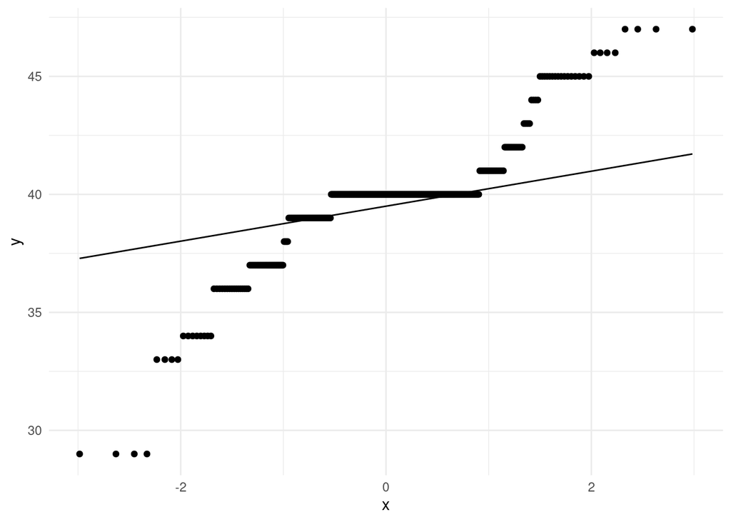

```r
ggplot(tidy_data, aes(sample = incubation_period)) +
  stat_qq() + stat_qq_line() +
  theme_minimal()
```

```r
# Shapiro-Wilk test for normality
shapiro.test(tidy_data$Chickmass)
```

```
##
##  Shapiro-Wilk normality test
##
## data:  tidy_data$Chickmass
## W = 0.97768, p-value = 3.2e-05
```

```r
shapiro.test(tidy_data$incubation_period)
```

```
##
##  Shapiro-Wilk normality test
##
## data:  tidy_data$incubation_period
## W = 0.82904, p-value < 2.2e-16
```

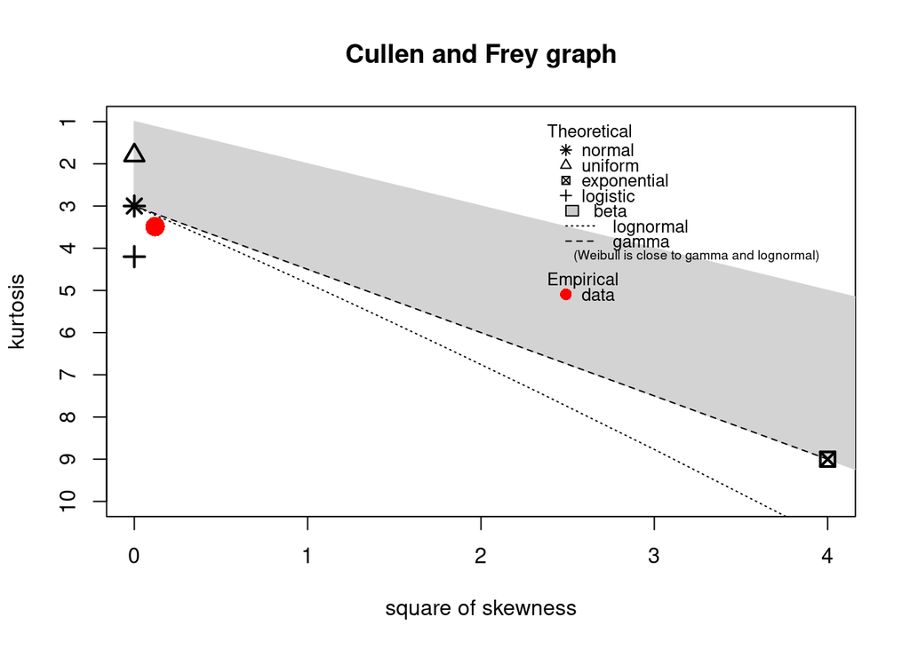

```
## summary statistics
## ------
## min:  2150   max:  4150
## median:  3100
## mean:  3078.966
## estimated sd:  371.7674
## estimated skewness:  0.3465738
## estimated kurtosis:  3.487155
```

```r
tidy_data_filtered <- tidy_data %>% filter(!is.na(Chickmass))
descdist(tidy_data_filtered$Chickmass, discrete = FALSE)
```